# Interim

### Plan for missigness

- We will impute education level with the median value due to so few missing.
- The two patients missing Serum protein C but no other serum readings will be imputed with a nearest neighbor imputation of other serum values.
- There will be four main models:
- Cognition outcome
  - w/wo serum data
- Function outcome
  - w/wo serum data

Each model will have it’s own sample size.

```r
# First filter down to serum data on all patients who are not missing all serum but protein c
serum_data_good <- serum_data %>%
  group_by(id) %>%
  mutate(
    missing_protein_c = sum((variable == "proteinC") & is.na(value))>0,
    missing_all_serum = sum(is.na(value)) == n()
  ) %>%
  ungroup() %>%
  filter(!missing_all_serum) %>%
  select(id, missing_protein_c, variable, value) %>%
  spread(variable, value)

# dataframe of just missing values for serum values.
# this is for later merging into gathered data after imputation
serum_data_bad <- serum_data %>%
  filter(!(id %in% serum_data_good$id))

full_obs <- serum_data_good %>%
  filter(!missing_protein_c)

train_data <- full_obs %>%
  select(-id, -missing_protein_c, -proteinC) %>%
  as.matrix()

missing_obs <- serum_data_good %>%
  filter(missing_protein_c)

test_data <- missing_obs %>%
  select(-id, -missing_protein_c, -proteinC) %>%
  as.matrix()

nearest_neighbors <- get.knnx(train_data, test_data, k = 10)

weighted_impute <- function(i = 1){
  nearest_values <- full_obs[nearest_neighbors$nn.index[i,],]$proteinC
  distances <- nearest_neighbors$nn.dist[i,]
  weighted.mean(nearest_values, 1/distances)
}

serum_data_imputed <- missing_obs %>%
  mutate(proteinC = purrr::map_dbl(1:2, weighted_impute)) %>%
  bind_rows(full_obs) %>%
  select(-missing_protein_c) %>%
  gather(variable, value, -id) %>%
  left_join(data_dict, by = 'variable') %>%
  bind_rows(serum_data_bad)

continuous_data_imputed <- continuous_data %>%
  mutate(value = ifelse(is.na(value) & variable == 'education_level', median(data$education_level, na.rm = TRUE), value))

gathered_data_imputed <- rbind(
  serum_data_imputed,
  continuous_data_imputed,
  binary_data,
  outcome_data
)
```

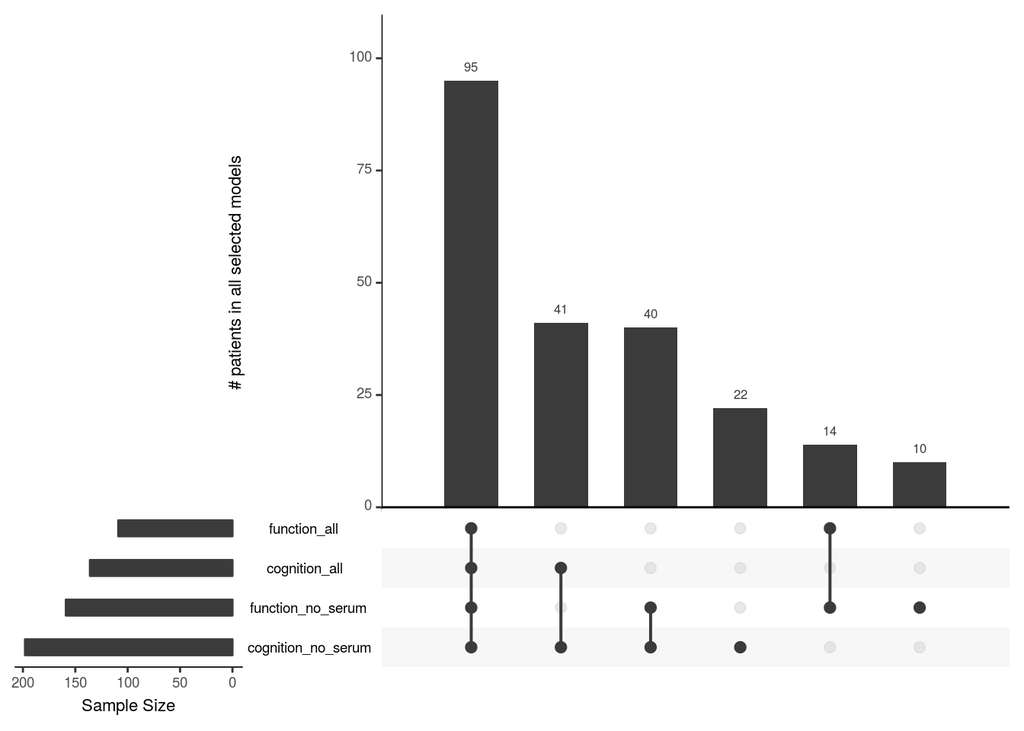

```r
missing_categories <- gathered_data_imputed %>%
  group_by(id) %>%
  summarise(
    missing_cognative = sum((variable %in% c('iqcode_score', 'iqcode_score')) & is.na(value)) > 0,
    missing_function = sum((variable %in% c('OARS_ADL_ED_0h_recode', 'OARS_ADL_ED_6m_recode')) & is.na(value)) > 0,
    missing_serum = sum((variable %in% serum_vars) & is.na(value)) > 0
  ) %>%
  transmute(
    id = id,
    cognition_all = !(missing_cognative | missing_serum),
    cognition_no_serum = !missing_cognative,
    function_all = !(missing_function | missing_serum),
    function_no_serum = !missing_function
  )

cognition_all <- missing_categories %>%
  filter(cognition_all) %>%
  .$id
cognition_no_serum <- missing_categories %>%
  filter(cognition_no_serum)%>%
  .$id

function_all <- missing_categories %>%
  filter(function_all)%>%
  .$id
function_no_serum <- missing_categories %>%
  filter(function_no_serum)%>%
  .$id

missing_categories %>%
  gather(model, value, -id) %>%
  mutate(value = value*1) %>%
  spread(model, value) %>%
  select(-id) %>%
  as.data.frame() %>%
  UpSetR::upset(
    order.by = 'freq',
    sets.x.label = 'Sample Size',
    mainbar.y.label = "# patients in all selected models"
    )
```

Our model sizes are as follow: cognition model with serum data: 136, cognition model without serum data: 198, function model with serum data: 109, function model without serum data: 159,

## Continuous Descriptives

For descriptive statistics we will include all patient data for non-serum variables and subset to only patients who have complete serum data for serum descriptives.

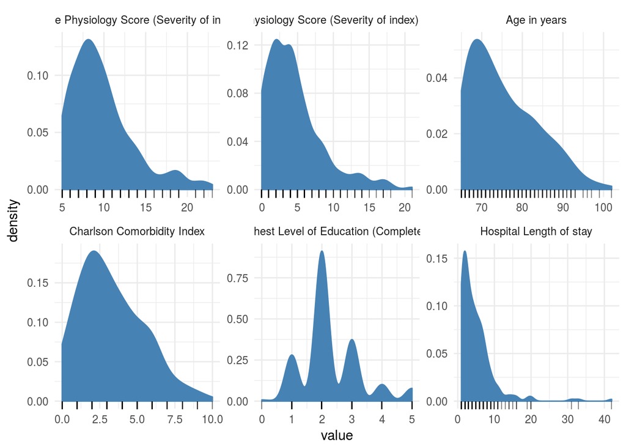

```r
continuous_data <- data_gathered %>%
  filter(variable %in% continuous_vars) %>%
  mutate(
    value =       ifelse(variable %in% log_transform_vars, log2(value), value),
    description = ifelse(variable %in% log_transform_vars, paste(description, '| log'), description)
  )

continuous_data %>%
  ggplot(aes(value)) +
  geom_density(fill = 'steelblue', color = 'steelblue') +
  geom_text(aes(x = value, y = 0), label = '|', alpha = 0.5, hjust = 0.5, vjust = 1) +
  facet_wrap(~description, scales = 'free', ncol = 3) +
  theme_minimal()
```

## Binary Descriptives

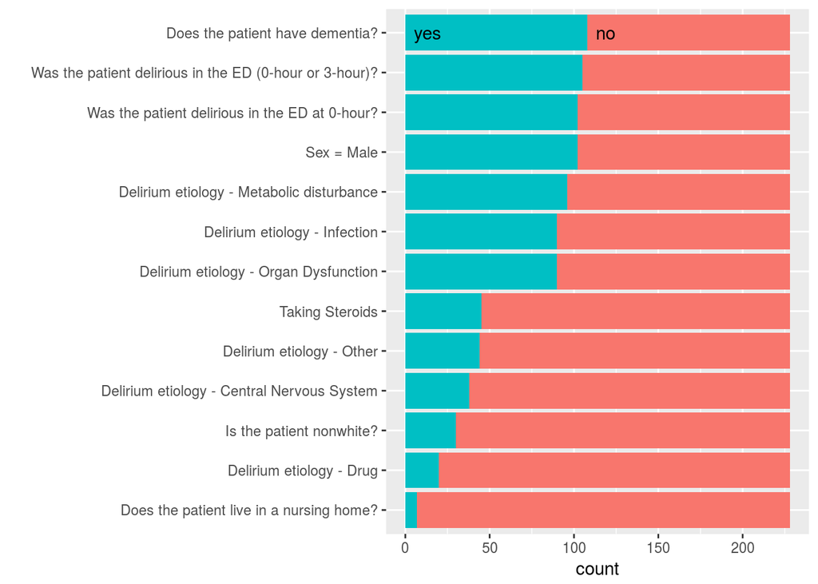

```r
binary_data <- data_gathered %>%
  filter(variable %in% binary_vars) %>%
  mutate(value = as.integer(value))

binary_arranged <- binary_data %>%
  group_by(description) %>%
  mutate(num_yes = sum(value)) %>%
  ungroup() %>%
  arrange(num_yes) %>%
  mutate(description = fct_inorder(factor(description)))

legend_data <- binary_arranged %>%
  group_by(description) %>%
  summarise(num_yes = first(num_yes)) %>%
  ungroup() %>%
  tail(1) %>% {
    new_df <- rbind(.,.)
    new_df$num_yes[1] = 0
    new_df
  } %>%
  mutate(label = c('yes', 'no'))

binary_arranged %>%
  mutate(value = ifelse(value == 1, 'yes', 'no')) %>%
  ggplot(aes(x = description)) +
  geom_bar(aes(fill = value), position = 'stack') +
  geom_text(
    data = legend_data,
    aes(y = num_yes, label = label),
    hjust = 0, nudge_y = 5) +
  coord_flip() +
  guides(fill = FALSE) +
  labs(x = '')
```